# Creating Similar Treatment Groups

Sam Matuba

9/6/2019

## Background

A local internet service provider (ISP) created two new versions of its software, with alternative ways of implementing a new feature. To find the product that would lead to the highest satisfaction among customers, the ISP conducted an experiment comparing users’ preferences for the two new versions versus the existing software.

The ISP ideally wants to find out which of the three software products causes the highest user satisfaction. It has identified three major potential lurking variables that might affect user satisfaction—gender, age, and hours per week of computer use.

## Dataset

- The population of interest to the ISP is the adults in a hypothetical city.
- Variables:
  - **age**: in years
  - **gender**: female or male
  - **comp**: hours per week of computer use

## Objectives

1. create a simple random sample as the basis for the experimental study of the population
2. use randomization to assign individuals to treatment groups
3. verify that randomization prevented the three treatment groups from being different with respect to the most obvious lurking variables

## R

The dataset contains the values of the three possible lurking variables.

*load dataset*

```r
load(file="computers.RData")
```

*variables*

```r
str(computers)
```

```
## 'data.frame':    20783 obs. of  3 variables:
##  $ age   : int  46 76 51 62 24 20 42 40 25 28 ...
##  $ gender: Factor w/ 2 levels "Female","Male": 1 1 1 1 1 1 1 1 1 1 ...
##  $ comp  : int  2 1 6 6 12 16 0 6 21 11 ...
```

*view dataset*

```r
head(computers)
```

```
##   age gender comp
## 1  46 Female    2
## 2  76 Female    1
## 3  51 Female    6
## 4  62 Female    6
## 5  24 Female   12
## 6  20 Female   16
```

*quick statistical summary*

```r
summary(computers)
```

```
##       age            gender           comp
##  Min.   : 18.00   Female:10368   Min.   : 0.0
##  1st Qu.: 31.00   Male  :10415   1st Qu.: 5.0
##  Median : 41.00                  Median :11.0
##  Mean   : 44.27                  Mean   :11.1
##  3rd Qu.: 55.00                  3rd Qu.:17.0
##  Max.   :107.00                  Max.   :37.0
```

1. *choose a simple random sample (SRS) of 450 people for the subjects in the study*

```r
random_sample = computers[sample(length(computers$age),450),]
summary(random_sample)
```

```
##       age           gender         comp
##  Min.   :18.00   Female:225   Min.   : 0.00
##  1st Qu.:30.00   Male  :225   1st Qu.: 5.25
##  Median :40.00                Median :12.00
##  Mean   :42.55                Mean   :11.84
##  3rd Qu.:52.00                3rd Qu.:17.00
##  Max.   :89.00                Max.   :35.00
```

2. *randomly assign the 450 subjects to one of three treatments denoted by versions “1”, “2”, and “3”*

```r
group = sample(1:3,450,replace=T);
random_sample = cbind(random_sample,group);
head(random_sample)
```

```
##       age gender comp group
## 13422  58 Female    1     3
## 6177   28   Male   21     2
## 9313   54 Female    7     2
## 1893   19 Female   15     1
## 9016   61   Male    4     2
## 2961   48 Female   11     1
```

3. *The distributions of the variables in the three groups are examined*

*Age*

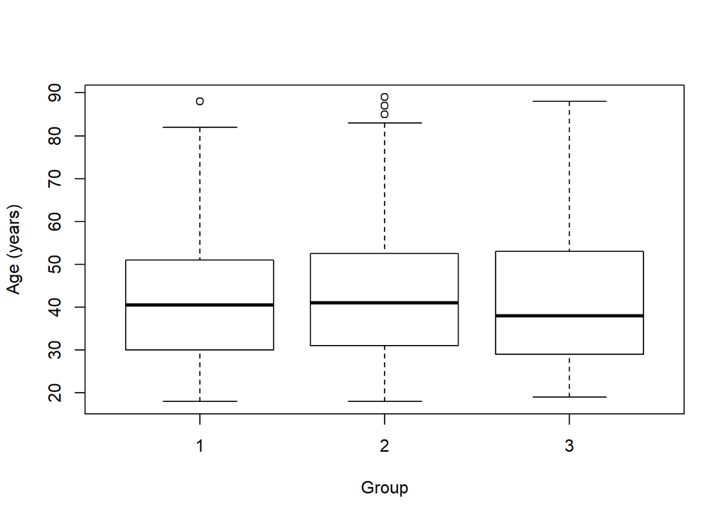

```r
boxplot(random_sample$age~random_sample$group, xlab="Group", ylab="Age (years)");
```

*Gender*

```r
two_way_table = table(random_sample$group,random_sample$gender)
prop.table(two_way_table,1)*100
```

```
##
##       Female     Male
##   1 50.00000 50.00000
##   2 48.17073 51.82927
##   3 52.23881 47.76119
```

*Comp*

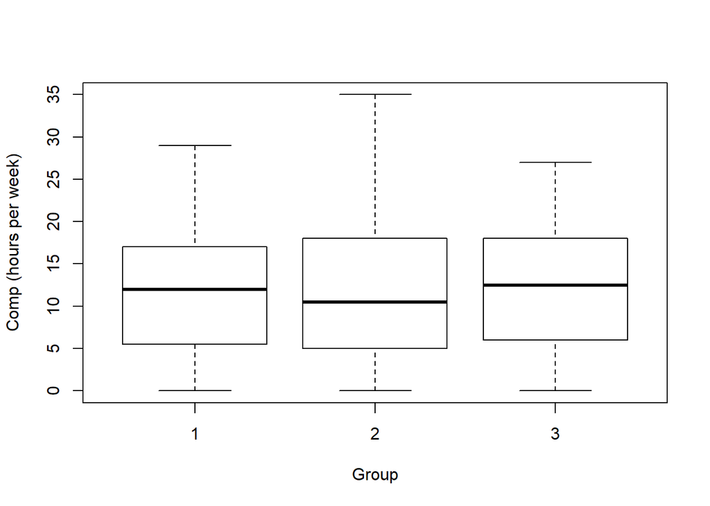

```r
boxplot(random_sample$comp~random_sample$group, xlab="Group", ylab="Comp (hours per week)")
```

## Analysis

Based on the box plots created, the distributions of ages and hours per week of computer use are similar across the three treatment groups. Similarly, the tabless of conditional percents suggests that the distributions of gender is also similar across the groups.

## Conclusion

In this exercise, 450 samples are taken from a population of 20783 adults using simple random sampling (SRS). The samples are then randomly assigned the to three different treatments, which are the three versions of the software. Finally, the possible effects of the lurking variables age, gender, and hours per week of computer use are eliminated by examining and confirming that their distributions are similar across all groups. Therefore, any difference in results across the treatment groups will be due to the differences in the three software versions, rather than age, gender, and hours per week of computer use.